© 2019 by Pearson Education, Inc. All Rights Reserved. The content in this notebook is based on the book [**Python for Programmers**](https://amzn.to/2VvdnxE).

```python
# enable high-res images in notebook
%config InlineBackend.figure_format = 'retina'
%matplotlib inline
```

# 14. Machine Learning: Classification, Regression and Clustering

# 14.1 Introduction to Machine Learning

- **Can we make computers learn?**
- **machine learning**—one of the most exciting and promising subfields of **artificial intelligence**
- **Rather than programming expertise into our applications, we program them to learn from data**
- We build machine-learning **models** that make **remarkably accurate predictions**
- The **“secret sauce”** is **data**—and **lots of it**
- **Quickly solve problems** that novices and experienced programmers alike probably would not have attempted just a few years ago
- Friendly, hands-on introduction to **simpler machine-learning techniques**
- Popular machine-learning applications (there are thousands)
  - **Chatbots, computer vision, fraud detection, handwriting recognition, language translation, medical diagnosis, predicting loan defaults, recommender systems, self-driving cars, sentiment analysis, spam filtering, stock price forecasting and voice recognition**

## 14.1.2 Two Main Types of Machine Learning

[figure not shown]

### Big Data and Big Computer Processing Power

- **Exploding, low-cost computing power, memory and secondary storage** enable us to think differently about solution approaches
- **Before machine learning**: “**I’m drowning in data** and I don’t know what to do with it”
- **With machine learning**: “**Flood me with big data** so I can use machine learning to extract insights and make valuable predictions from the data”

# 14.2 Case Study: Classification with k-Nearest Neighbors and the Digits Dataset, Part 1

- To process mail efficiently and route each letter to the correct destination, postal service computers must be able to **scan handwritten names, addresses and zip codes** and **recognize the letters and digits**
- **Scikit-learn** enables even novice programmers to make such machine-learning problems manageable

### Supervised Machine Learning: Classification

- Attempt to **predict the distinct class** (category) to which a **sample** belongs
  - **Binary classification**—**two** classes (e.g., “dog” or “cat”)
- [**Digits dataset**](http://scikit-learn.org/stable/datasets/index.html#optical-recognition-of-handwritten-digits-dataset) bundled with scikit-learn
  - 8-by-8 pixel images representing 1797 hand-written digits (0 through 9)
- Goal: **Predict** which digit an image represents
  - **Multi-classification**—**10 possible digits** (the classes)
- Train a classification model using **labeled data**—know in advance each digit’s class
- We’ll use one of the simplest machine-learning classification algorithms, **k-nearest neighbors (k-NN)**, to **recognize handwritten digits**

## 14.2.1 k-Nearest Neighbors Algorithm (k-NN)

- Predict a sample’s class by looking at the *k* training samples **nearest in "distance"** to the **sample**
- Filled dots represent four distinct classes—A (blue), B (green), C (red) and D (purple)
- **Class with the most “votes” wins**
  - **Odd *k* value** **avoids ties** — there’s never an equal number of votes

[figure not shown]

## 14.2.2 Loading the Dataset with the **`load_digits` Function**

- Returns a **`Bunch`** object containing **digit samples** and **metadata**
- A **`Bunch`** is a dictionary with additional **dataset-specific attributes**

```python
from sklearn.datasets import load_digits
```

```python
digits = load_digits()
```

### Displaying Digits Dataset's Description

- **Digits dataset** is a subset of the [**UCI (University of California Irvine) ML hand-written digits dataset**](http://archive.ics.uci.edu/ml/datasets/Optical+Recognition+of+Handwritten+Digits)
  - Original dataset: **5620 samples**—3823 for **training** and 1797 for **testing**
  - **Digits dataset**: Only the **1797 testing samples**
- A Bunch’s **`DESCR` attribute** contains dataset's description
  - Each sample has **`64` features** (**`Number of Attributes`**) that represent an **8-by-8 image** with **pixel values `0`–`16`** (**`Attribute Information`**)
  - **No missing values** (**`Missing Attribute Values`**)
- **64 features** may seem like a lot
  - Datasets can have **hundreds**, **thousands** or even **millions of features**
  - Processing datasets like these can require enormous computing capabilities

```python
print(digits.DESCR)
```

```
.. _digits_dataset:

Optical recognition of handwritten digits dataset
--------------------------------------------------

**Data Set Characteristics:**

    :Number of Instances: 5620
    :Number of Attributes: 64
    :Attribute Information: 8x8 image of integer pixels in the range 0..16.
    :Missing Attribute Values: None
    :Creator: E. Alpaydin (alpaydin '@' boun.edu.tr)
    :Date: July; 1998

This is a copy of the test set of the UCI ML hand-written digits datasets
https://archive.ics.uci.edu/ml/datasets/Optical+Recognition+of+Handwritten+Digits

The data set contains images of hand-written digits: 10 classes where
each class refers to a digit.

Preprocessing programs made available by NIST were used to extract
normalized bitmaps of handwritten digits from a preprinted form. From a
total of 43 people, 30 contributed to the training set and different 13
to the test set. 32x32 bitmaps are divided into nonoverlapping blocks of
4x4 and the number of on pixels are counted in each block. This generates
an input matrix of 8x8 where each element is an integer in the range
0..16. This reduces dimensionality and gives invariance to small
distortions.

For info on NIST preprocessing routines, see M. D. Garris, J. L. Blue, G.
T. Candela, D. L. Dimmick, J. Geist, P. J. Grother, S. A. Janet, and C.
L. Wilson, NIST Form-Based Handprint Recognition System, NISTIR 5469,
1994.

.. topic:: References

  - C. Kaynak (1995) Methods of Combining Multiple Classifiers and Their
    Applications to Handwritten Digit Recognition, MSc Thesis, Institute of
    Graduate Studies in Science and Engineering, Bogazici University.
  - E. Alpaydin, C. Kaynak (1998) Cascading Classifiers, Kybernetika.
  - Ken Tang and Ponnuthurai N. Suganthan and Xi Yao and A. Kai Qin.
    Linear dimensionalityreduction using relevance weighted LDA. School of
    Electrical and Electronic Engineering Nanyang Technological University.
    2005.
  - Claudio Gentile. A New Approximate Maximal Margin Classification
    Algorithm. NIPS. 2000.
```

### Checking the Sample and Target Sizes (1 of 2)

- `Bunch` object’s **`data`** and **`target`** attributes are **NumPy arrays**:
  - **`data` array**: The **1797 samples** (digit images), each with **64 features** with values **0** (white) to **16** (black), representing **pixel intensities**

[figure not shown]

  - **`target` array**: The **images’ labels**, (classes) indicating **which digit** each image represents

```python
digits.target[:20]  # first twenty target values
```

```
array([0, 1, 2, 3, 4, 5, 6, 7, 8, 9, 0, 1, 2, 3, 4, 5, 6, 7, 8, 9])
```

### Checking the Sample and Target Sizes (2 of 2)

- Confirm number of **samples** and **features** (per sample) via `data` array’s **`shape`**

```python
digits.data.shape
```

```
(1797, 64)
```

- Confirm that **number of target values matches number of samples** via `target` array’s `shape`

```python
digits.target.shape
```

```
(1797,)
```

### A Sample Digit Image

- Images are **two-dimensional**—width and a height in pixels
- Digits dataset's `Bunch` object has an **`images` attribute**
  - Each element is an **8-by-8 array** representing a **digit image’s pixel intensities**
- Scikit-learn stores the intensity values as **NumPy type `float64`**

```python
digits.images[13]  # show array for sample image at index 13
```

```
array([[ 0.,  2.,  9., 15., 14.,  9.,  3.,  0.],
       [ 0.,  4., 13.,  8.,  9., 16.,  8.,  0.],
       [ 0.,  0.,  0.,  6., 14., 15.,  3.,  0.],
       [ 0.,  0.,  0., 11., 14.,  2.,  0.,  0.],
       [ 0.,  0.,  0.,  2., 15., 11.,  0.,  0.],
       [ 0.,  0.,  0.,  0.,  2., 15.,  4.,  0.],
       [ 0.,  1.,  5.,  6., 13., 16.,  6.,  0.],
       [ 0.,  2., 12., 12., 13., 11.,  0.,  0.]])
```

- Visualization of `digits.images[13]`

[figure not shown]

### Preparing the Data for Use with Scikit-Learn (1 of 2)

- Scikit-learn estimators require samples to be stored in a **two-dimensional array of floating-point values** (or **list of lists** or **pandas `DataFrame`**):
  - Each **row** represents one **sample**
  - Each **column** in a given row represents one **feature** for that sample
- Multi-dimensional data samples must be **flattened** into a **one-dimensional array**
- For **categorical features** (e.g., **strings** like `'spam'` or `'not-spam'`), you’d have to **preprocess** those features into **numerical values**—known as **one-hot encoding** (discussed later in deep learning)

### Preparing the Data for Use with Scikit-Learn (2 of 2)

- **`load_digits`** returns the **preprocessed data** ready for machine learning
- **8-by-8 array `digits.images[13]`** corresponds to **1-by-64 array `digits.data[13]`**:

```python
digits.data[13]
```

```
array([ 0.,  2.,  9., 15., 14.,  9.,  3.,  0.,  0.,  4., 13.,  8.,  9.,
       16.,  8.,  0.,  0.,  0.,  0.,  6., 14., 15.,  3.,  0.,  0.,  0.,
        0., 11., 14.,  2.,  0.,  0.,  0.,  0.,  0.,  2., 15., 11.,  0.,
        0.,  0.,  0.,  0.,  0.,  2., 15.,  4.,  0.,  0.,  1.,  5.,  6.,
       13., 16.,  6.,  0.,  0.,  2., 12., 12., 13., 11.,  0.,  0.])
```

## 14.2.3 Visualizing the Data

- **Data exploration**—familiarize yourself with the data
- **Visualizing** helps you get a sense of your data

### Creating the Diagram

- **Color map `plt.cm.gray_r`** is for **grayscale** with **0 for white**
- [**Matplotlib’s color map names**](https://matplotlib.org/examples/color/colormaps_reference.html)

```python
import matplotlib.pyplot as plt
```

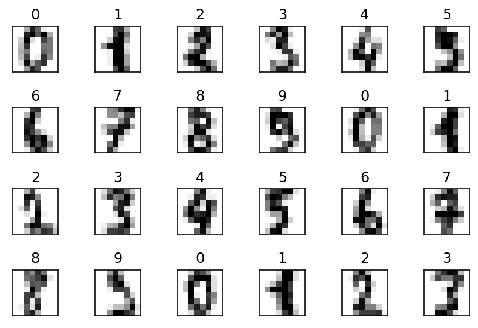

```python
figure, axes = plt.subplots(nrows=4, ncols=6, figsize=(6, 4))

for item in zip(axes.ravel(), digits.images, digits.target):
    axes, image, target = item
    axes.imshow(image, cmap=plt.cm.gray_r)
    axes.set_xticks([])  # remove x-axis tick marks
    axes.set_yticks([])  # remove y-axis tick marks
    axes.set_title(target)
plt.tight_layout()
```

## 14.2.4 Splitting the Data for Training and Testing

- Typically **train** a model with a **subset of a dataset**
- **Save a portion for testing**, so you can evaluate a model’s performance using **unseen data**
- Function **`train_test_split`** **shuffles** the data to **randomize** it, then **splits** the **samples** in the `data` array and the **target values** in the `target` array into **training** and **testing sets**
  - Shuffling helps ensure that the **training and testing sets** have **similar characteristics**
- Convention:
  - **Uppercase `X`** represents **samples**
  - **Lowercase `y`** represents **target values**

```python
from sklearn.model_selection import train_test_split
```

```python
X_train, X_test, y_train, y_test = train_test_split(
    digits.data, digits.target, random_state=11)  # random_state for reproducibility
```

- Scikit-learn bundled classification datasets have **balanced classes**
  - Samples are **divided evenly** among the classes
  - **Unbalanced classes** could lead to incorrect results

### Training and Testing Set Sizes

- **By default**, `train_test_split` reserves **75%** of the data for **training** and **25%** for **testing**
  - Customizable: See how in my [**Python Fundamentals LiveLessons** videos](https://learning.oreilly.com/videos/python-fundamentals/9780135917411/9780135917411-PFLL_Lesson14_11) or in [**Python for Programmers**, Section 14.2.4](https://learning.oreilly.com/library/view/python-for-programmers/9780135231364/ch14.xhtml#ch14lev2sec8)

```python
X_train.shape
```

```
(1347, 64)
```

```python
X_test.shape
```

```
(450, 64)
```

## 14.2.5 Creating the Model

- In **scikit-learn**, **models** are called **estimators**
- **`KNeighborsClassifier`** estimator implements the **k-nearest neighbors algorithm**

```python
from sklearn.neighbors import KNeighborsClassifier
```

```python
knn = KNeighborsClassifier()
```

## 14.2.6 Training the Model with the `KNeighborsClassifier` Object’s **`fit` method** (1 of 2)

- Load **sample training set (`X_train`)** and **target training set (`y_train`)** into the estimator

```python
knn.fit(X=X_train, y=y_train)
```

```
KNeighborsClassifier()
```

- **`n_neighbors`** corresponds to *k* in the k-nearest neighbors algorithm
- [`KNeighborsClassifier` default settings](http://scikit-learn.org/stable/modules/generated/sklearn.neighbors.KNeighborsClassifier.html)

## 14.2.6 Training the Model with the `KNeighborsClassifier` Object’s **`fit` method** (2 of 2)

- **`fit` normally loads data** into an **estimator** then performs complex calculations **behind the scenes** that **learn** from the data to train a model
- **`KNeighborsClassifier`’s `fit` method** **just loads the data**
  - **No initial learning process**
  - The **estimator** is **lazy** — work is performed only when you use it to make predictions
- **Lots of models** have **significant training phases** that can take minutes, hours, days or more
  - High-performance **GPUs** and **TPUs** can significantly **reduce model training time**

## 14.2.7 Predicting Digit Classes with the `KNeighborsClassifier`’s **`predict` method** (1 of 2)

- Returns an array containing the **predicted class of each test image**:

```python
predicted = knn.predict(X=X_test)
```

```python
expected = y_test
```

- **`predicted` digits** vs. **`expected` digits** for the first 20 test samples—see **index 18**

```python
predicted[:20]
```

```
array([0, 4, 9, 9, 3, 1, 4, 1, 5, 0, 4, 9, 4, 1, 5, 3, 3, 8, 5, 6])
```

```python
expected[:20]
```

```
array([0, 4, 9, 9, 3, 1, 4, 1, 5, 0, 4, 9, 4, 1, 5, 3, 3, 8, 3, 6])
```

## 14.2.7 Predicting Digit Classes with the `KNeighborsClassifier`’s **`predict` method** (2 of 2)

- Locate **all incorrect predictions** for the **entire test set**:

```python
wrong = [(p, e) for (p, e) in zip(predicted, expected) if p != e]
```

```python
wrong
```

```
[(5, 3),
 (8, 9),
 (4, 9),
 (7, 3),
 (7, 4),
 (2, 8),
 (9, 8),
 (3, 8),
 (3, 8),
 (1, 8)]
```

- **Incorrectly predicted only 10 of the 450 test samples**

# 14.3 Case Study: Classification with k-Nearest Neighbors and the Digits Dataset, Part 2

## 14.3.1 Metrics for Measuring Model Accuracy

### Estimator Method `score`

- Returns an **indication of how well the estimator performs** on **test data**
- For **classification estimators**, returns the **prediction accuracy** for the test data:

```python
print(f'{knn.score(X_test, y_test):.2%}')
```

```
97.78%
```

- `kNeighborsClassifier` with default *k* of 5 achieved **97.78% prediction accuracy** using only the estimator’s **default parameters**
- Can use **hyperparameter tuning** to try to determine the **optimal value for *k***

### Confusion Matrix (1 of 2)

- Shows correct and incorrect predicted values (the **hits** and **misses**) for a given class

```python
from sklearn.metrics import confusion_matrix
```

```python
confusion = confusion_matrix(y_true=expected, y_pred=predicted)
```

```python
confusion
```

```
array([[45,  0,  0,  0,  0,  0,  0,  0,  0,  0],
       [ 0, 45,  0,  0,  0,  0,  0,  0,  0,  0],
       [ 0,  0, 54,  0,  0,  0,  0,  0,  0,  0],
       [ 0,  0,  0, 42,  0,  1,  0,  1,  0,  0],
       [ 0,  0,  0,  0, 49,  0,  0,  1,  0,  0],
       [ 0,  0,  0,  0,  0, 38,  0,  0,  0,  0],
       [ 0,  0,  0,  0,  0,  0, 42,  0,  0,  0],
       [ 0,  0,  0,  0,  0,  0,  0, 45,  0,  0],
       [ 0,  1,  1,  2,  0,  0,  0,  0, 39,  1],
       [ 0,  0,  0,  0,  1,  0,  0,  0,  1, 41]])
```

### Confusion Matrix (2 of 2)

- **Correct predictions** shown on **principal diagonal** from top-left to bottom-right
- **Nonzero values** not on **principal diagonal** indicate **incorrect predictions**
- Each **row** represents **one distinct class** (0–9)
- **Columns** specify how many **test samples** were classified into classes 0–9
- **Row 0** shows digit class **`0`**—**all 0s were predicted correctly**

  > `[45, 0, 0, 0, 0, 0, 0, 0, 0, 0]`
- **Row 8** shows digit class **`8`**—**five 8s were predicted incorrectly**

  > `[ 0, 1, 1, 2, 0, 0, 0, 0, 39, 1]`
  - **Correctly predicted 88.63%** (39 of 44) of `8`s
  - 8s harder to recognize

### Visualizing the Confusion Matrix

- A **heat map** displays **values** as **colors**
- Convert the **confusion matrix** into a **`DataFrame`**, then graph it
- **Principal diagonal** and **incorrect predictions** stand out nicely in **heat map**

```python
import pandas as pd
```

```python
confusion_df = pd.DataFrame(confusion, index=range(10), columns=range(10))
```

```python
confusion_df
```

|  | 0 | 1 | 2 | 3 | 4 | 5 | 6 | 7 | 8 | 9 |
| --- | --- | --- | --- | --- | --- | --- | --- | --- | --- | --- |
| 0 | 45 | 0 | 0 | 0 | 0 | 0 | 0 | 0 | 0 | 0 |
| 1 | 0 | 45 | 0 | 0 | 0 | 0 | 0 | 0 | 0 | 0 |
| 2 | 0 | 0 | 54 | 0 | 0 | 0 | 0 | 0 | 0 | 0 |
| 3 | 0 | 0 | 0 | 42 | 0 | 1 | 0 | 1 | 0 | 0 |
| 4 | 0 | 0 | 0 | 0 | 49 | 0 | 0 | 1 | 0 | 0 |
| 5 | 0 | 0 | 0 | 0 | 0 | 38 | 0 | 0 | 0 | 0 |
| 6 | 0 | 0 | 0 | 0 | 0 | 0 | 42 | 0 | 0 | 0 |
| 7 | 0 | 0 | 0 | 0 | 0 | 0 | 0 | 45 | 0 | 0 |
| 8 | 0 | 1 | 1 | 2 | 0 | 0 | 0 | 0 | 39 | 1 |
| 9 | 0 | 0 | 0 | 0 | 1 | 0 | 0 | 0 | 1 | 41 |

```python
import seaborn as sns
```

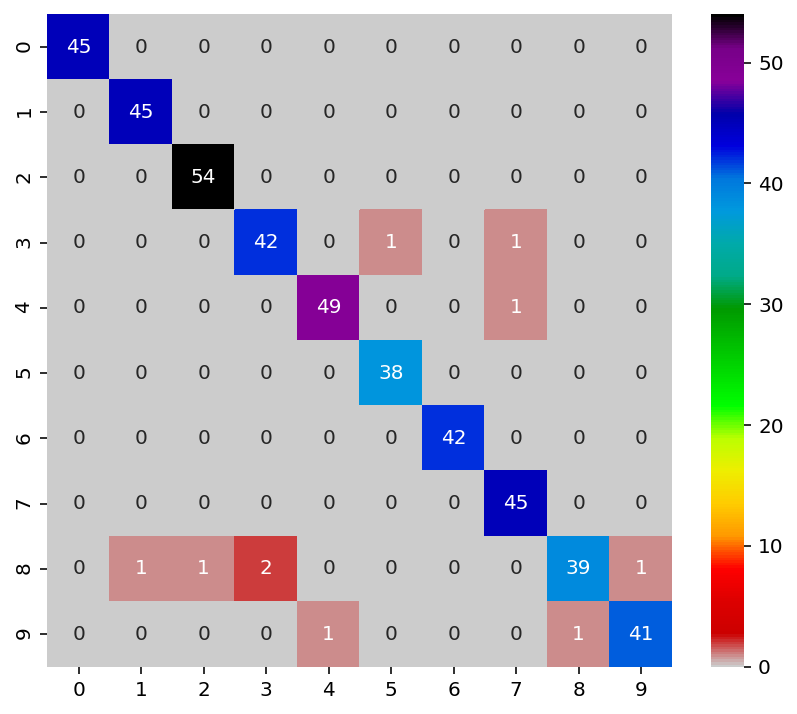

```python
figure = plt.figure(figsize=(7, 6))
axes = sns.heatmap(confusion_df, annot=True,
                   cmap=plt.cm.nipy_spectral_r)
```

## 14.3.2 K-Fold Cross-Validation

- Uses **all of your data** for **training and testing**
- Gives a better sense of how well your model will make predictions
- **Splits the dataset** into *k* equal-size folds (unrelated to **k** in the k-nearest neighbors algorithm)
- **Repeatedly trains** your model with *k* – 1 folds and **test the model** with the **remaining fold**
- Consider using *k* = 10 with **folds numbered 1 through 10**
  - **train** with **folds 1–9**, then **test** with **fold 10**
  - **train** with **folds 1–8 and 10**, then **test** with **fold 9**
  - **train** with **folds 1–7** and **9–10**, then **test** with **fold 8**
  - ...

### `KFold` Class

- **`KFold`** class and function **`cross_val_score`** perform **k-fold cross validation**
- **`n_splits=10`** specifies the **number of folds**
- **`shuffle=True`** **randomizes** the data before **splitting it into folds**
  - Particularly **important** if the **samples** might be **ordered** or **grouped** (as in **Iris dataset** we'll see later)

```python
from sklearn.model_selection import KFold
```

```python
kfold = KFold(n_splits=10, random_state=11, shuffle=True)
```

### Calling Function `cross_val_score` to Train and Test Your Model (1 of 2)

- **`estimator=knn`** — **estimator** to validate
- **`X=digits.data`** — **samples** to use for training and testing
- **`y=digits.target`** — **target predictions** for the samples
- **`cv=kfold`** — **cross-validation generator** that defines how to **split** the **samples** and **targets** for training and testing

```python
from sklearn.model_selection import cross_val_score
```

```python
scores = cross_val_score(estimator=knn, X=digits.data, y=digits.target, cv=kfold)
```

### Calling Function `cross_val_score` to Train and Test Your Model (2 of 2)

- Lowest accuracy was **97.78%** — one was **100%**

```python
scores  # array of accuracy scores for each fold
```

```
array([0.97777778, 0.99444444, 0.98888889, 0.97777778, 0.98888889,
       0.99444444, 0.97777778, 0.98882682, 1.        , 0.98324022])
```

```python
print(f'Mean accuracy: {scores.mean():.2%}')
```

```
Mean accuracy: 98.72%
```

- Mean accuracy even better than the **97.78% we achieved** when we **trained** the model with **75%** of the data and **tested** the model with **25%** earlier

## 14.3.3 Running Multiple Models to Find the Best One (1 of 3)

- **Difficult to know in advance** which machine learning model(s) will **perform best for a given dataset**
  - Especially when they hide the details of how they operate
- Even though the **`KNeighborsClassifier`** predicts digit images with a high degree of accuracy, it’s **possible** that other estimators are **even more accurate**
- Let’s **compare** **`KNeighborsClassifier`**, **`SVC`** and **`GaussianNB`**

## 14.3.3 Running Multiple Models to Find the Best One (2 of 3)

```python
from sklearn.svm import SVC
```

```python
from sklearn.naive_bayes import GaussianNB
```

- **Create the estimators**
- To avoid a scikit-learn warning, we supplied a keyword argument when creating the **`SVC`** estimator
  - This argument’s value will become the default in scikit-learn version 0.22

```python
estimators = {
    'KNeighborsClassifier': knn,
    'SVC': SVC(gamma='scale'),
    'GaussianNB': GaussianNB()}
```

## 14.3.3 Running Multiple Models to Find the Best One (3 of 3)

- **Execute the models**:

```python
for estimator_name, estimator_object in estimators.items():
    kfold = KFold(n_splits=10, random_state=11, shuffle=True)
    scores = cross_val_score(estimator=estimator_object,
        X=digits.data, y=digits.target, cv=kfold)
    print(f'{estimator_name:>20}: ' +
          f'mean accuracy={scores.mean():.2%}; ' +
          f'standard deviation={scores.std():.2%}')
```

```
KNeighborsClassifier: mean accuracy=98.72%; standard deviation=0.75%
                 SVC: mean accuracy=98.72%; standard deviation=0.79%
          GaussianNB: mean accuracy=84.48%; standard deviation=3.47%
```

- **`KNeighborsClassifier`** and **`SVC`** estimators’ accuracies are identical so we might want to **perform hyperparameter tuning** on each to determine the best

## 14.3.4 Hyperparameter Tuning (1 of 3)

- In real-world machine learning studies, you’ll want to **tune hyperparameters** to choose values that produce the **best possible predictions**
- To **determine** the **best value** for *k* in the **kNN algorithm**, **try different values** and **compare performance**
- Scikit-learn also has **automated hyperparameter tuning** capabilities

## 14.3.4 Hyperparameter Tuning (2 of 3)

- Create `KNeighborsClassifiers` with odd **k** values from 1 through 19
- Perform **k-fold cross-validation** on each

```python
for k in range(1, 20, 2):  # k is an odd value 1-19; odds prevent ties
    kfold = KFold(n_splits=10, random_state=11, shuffle=True)
    knn = KNeighborsClassifier(n_neighbors=k)
    scores = cross_val_score(estimator=knn,
        X=digits.data, y=digits.target, cv=kfold)
    print(f'k={k:<2}; mean accuracy={scores.mean():.2%}; ' +
          f'standard deviation={scores.std():.2%}')
```

```
k=1 ; mean accuracy=98.83%; standard deviation=0.58%
k=3 ; mean accuracy=98.78%; standard deviation=0.78%
k=5 ; mean accuracy=98.72%; standard deviation=0.75%
k=7 ; mean accuracy=98.44%; standard deviation=0.96%
k=9 ; mean accuracy=98.39%; standard deviation=0.80%
k=11; mean accuracy=98.39%; standard deviation=0.80%
k=13; mean accuracy=97.89%; standard deviation=0.89%
k=15; mean accuracy=97.89%; standard deviation=1.02%
k=17; mean accuracy=97.50%; standard deviation=1.00%
k=19; mean accuracy=97.66%; standard deviation=0.96%
```

## 14.3.4 Hyperparameter Tuning (3 of 3)

- **Machine learning** is not without its **costs**, especially in **big data** and **deep learning**
- **Compute time grows with *k***, because **k-NN** needs to perform **more calculations** to find the **nearest neighbors**
- Can use function **`cross_validate`** to perform cross-validation **and** time the results

# 14.4 Case Study: Time Series and Simple Linear Regression

[**Note:** I no longer cover this case study in this webinar due to lack of time. See the full presentation in my [**Python Fundamentals** videos (8 videos in this case study)](https://learning.oreilly.com/videos/python-fundamentals/9780135917411/9780135917411-PFLL_Lesson14_23)]

- **Simple linear regression** is the **simplest** regression algorithm
- Given a collection of numeric values representing an **independent variable** and a **dependent variable**, simple linear regression **describes the relationship between these variables with a straight line**, known as the **regression line**
- Using a **time series** of average New York City January high-temperature data for 1895 through 2018, we'll
  - Perform **simple linear regression**
  - Display a **scatter plot** with a **regression line**
  - Use the **coefficient** and **intercept values** calculated by the estimator to **make predictions**
- Temperature data stored in **`ave_hi_nyc_jan_1895-2018.csv`**

# 14.5 Case Study: Multiple Linear Regression with the California Housing Dataset

[**Note:** I no longer cover this case study in this webinar due to lack of time. See the full presentation in my [**Python Fundamentals** videos (10 videos in this case study)](https://learning.oreilly.com/videos/python-fundamentals/9780135917411/9780135917411-PFLL_Lesson14_31)]

- [**California Housing dataset**](http://lib.stat.cmu.edu/datasets) bundled with scikit-learn
- **Larger real-world dataset** **20,640 samples**, each with **eight numerical features**
  - Pace, R. Kelley and Ronald Barry, Sparse Spatial Autoregressions, Statistics and Probability Letters, 33 (1997) 291-297. Submitted to the StatLib Datasets Archive by Kelley Pace (kpace@unix1.sncc.lsu.edu). [9/Nov/99].
- Perform **multiple linear regression** using **all eight numerical features**
  - Make **more sophisticated housing price predictions** than if we were to use only a **single feature** or a **subset of the features**
- **`LinearRegression`** estimator performs **multiple linear regression** by default

# 14.6 Case Study: Unsupervised Machine Learning, Part 1—Dimensionality Reduction (1 of 3)

# 14.6 Case Study: Unsupervised Machine Learning, Part 1—Dimensionality Reduction (2 of 3)

- Must **reduce** the data to **two** or **three dimensions**
- **Unsupervised machine learning** technique called **dimensionality reduction**
  - There are also **supervised dimensionality-reduction** techniques
- **Patterns in the data** might help you **choose the most appropriate machine learning algorithms** to use
- See **clusters** of points? Might indicate **distinct classes** of information within the dataset
  - So a **classification algorithm** might be appropriate.
  - You’d still need to **determine the class** of the samples in each cluster
  - This might require **consulting with a domain expert** and **studying samples in a cluster** to see **what they have in common**

# 14.6 Case Study: Unsupervised Machine Learning, Part 1—Dimensionality Reduction (3 of 3)

- **Dimensionality reduction** also serves other purposes
  - **Training estimators on big data** with **significant numbers of dimensions** can take **hours, days, weeks or longer**.
  - **Difficult for humans to think about highly dimensional data**
  - Could eliminate or combine **closely correlated features** to **improve training performance**
    - Might **reduce the accuracy** of the model

### Loading the Digits Dataset

- Let’s **ignore Digits dataset labels** and use **dimensionality reduction** to help visualize the data in two dimensions

```python
from sklearn.datasets import load_digits
```

```python
digits = load_digits()
```

### Creating a `TSNE` Estimator for Dimensionality Reduction (1 of 2)

- Uses an algorithm called **t-distributed Stochastic Neighbor Embedding (t-SNE)** to analyze a dataset’s features and reduce them to the specified number of dimensions
  - [Algorithm’s details](https://scikit-learn.org/stable/modules/manifold.html#t-sne) are **beyond scope**
  - We first tried the popular **`PCA`** (principal components analysis) estimator but did not like the results, so we switched to **`TSNE`**

### Creating a `TSNE` Estimator for Dimensionality Reduction (2 of 2)

- Create a `TSNE` object that **reduces a dataset’s features to two dimensions**
- `random_state` for **reproducibility of the “render sequence”** when we display the digit clusters

```python
from sklearn.manifold import TSNE
```

```python
tsne = TSNE(n_components=2, random_state=11)
```

### Transforming the Digits Dataset’s Features into Two Dimensions

- **Lecture note: Takes about 15-20 seconds, so run code first**
- Two steps
  - **Train the estimator** with the dataset
  - **Use the estimator** to **transform** the data into the **specified number of dimensions**
- Can **perform separately** with `TSNE` methods **`fit`** and **`transform`**
- Perform in **one statement** using **`fit_transform`**
  - Returns array with **same number of rows** as `digits.data` and **two columns**

```python
reduced_data = tsne.fit_transform(digits.data)
```

```python
reduced_data.shape
```

```
(1797, 2)
```

### Visualizing the Reduced Data (1 of 2)

- Rather than Seaborn’s `scatterplot` function, use Matplotlib’s **`scatter` function**
  - Returns collection of plotted items, which we’ll use in a second scatter plot

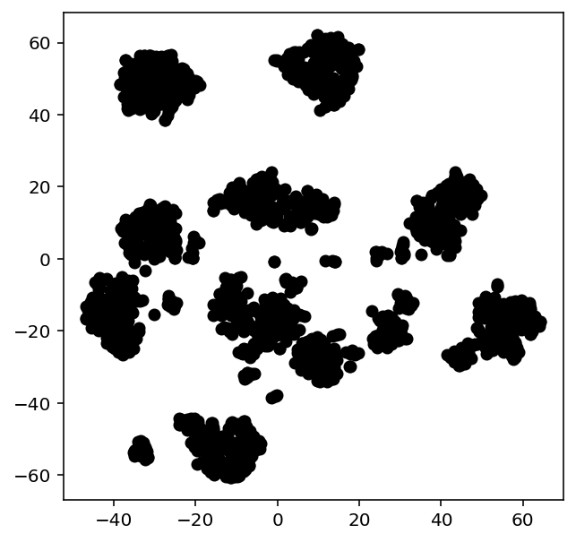

```python
import matplotlib.pyplot as plt
figure = plt.figure(figsize=(5, 5))
dots = plt.scatter(reduced_data[:, 0], reduced_data[:, 1], c='black')
```

### Visualizing the Reduced Data (2 of 2)

- **Did not label axes** — they **do not correspond to specific features** of the original dataset
- **New features** produced by **`TSNE`** could be quite different from **dataset’s original features**
- Clear **clusters** of related data points
- Appear to be **11 main clusters, rather than 10**
- Some **"loose" data points**
  - Makes sense because, as you saw, **some digits were difficult to classify**

### Visualizing the Reduced Data with Different Colors for Each Digit

- **Don’t know** whether all the **items in each cluster** represent the **same digit**
  - If not, then the clusters are not helpful
- Use **`target`s** in **Digits dataset** to **color the dots** to see whether clusters indeed represent specific digits
- **`c=digits.target`** — use `target` values determine dot colors
- **`cmap=plt.cm.get_cmap('nipy_spectral_r', 10)`** — **color map** to use
  - Specifically use **10 distinct colors** for the 10 digits
- Last statement adds color bar key

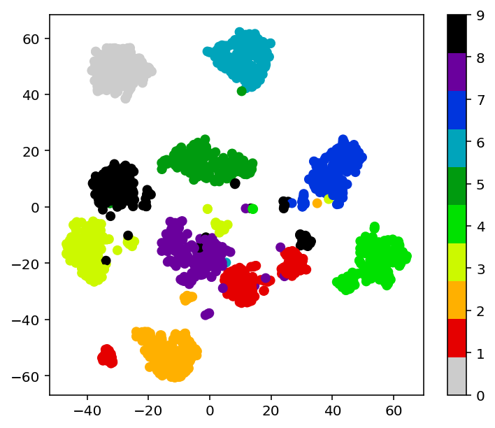

```python
figure = plt.figure(figsize=(6, 5))

dots = plt.scatter(reduced_data[:, 0], reduced_data[:, 1],
    c=digits.target, cmap=plt.cm.get_cmap('nipy_spectral_r', 10))

colorbar = plt.colorbar(dots)
```

### 3D Plot

- **Lecture Note: Run `digits3d.py` first**
- Can use Matplotlib’s **`Axes3D`** for plotting in three-dimensional graphs
- Run provided **`digits3d.py`** file from the command line
  - Diagram in JupyterLab is not interactive without additional tools installed

# 14.7 Case Study: Unsupervised Machine Learning, Part 2—k-Means Clustering (1 of 2)

- **Simplest** unsupervised machine learning algorithm
- Analyze **unlabeled samples** and **attempt to place them in clusters**
- *k* hyperparameter represents **number of clusters** to impose on the data
- Organizes clusters using **distance calculations** similar to the **k-NN classification**

# 14.7 Case Study: Unsupervised Machine Learning, Part 2—k-Means Clustering (2 of 2)

- Each **cluster** is grouped around a **centroid** (cluster’s **center point**)
- Initially, the algorithm **chooses *k* centroids at random** from **dataset’s samples**
- **Remaining samples** placed in the cluster whose **centroid is the closest**
- **Centroids are iteratively recalculated** and **samples re-assigned** to clusters until, for all clusters, **distances** from a given centroid to the samples in its cluster are **minimized** Results are:
  - **one-dimensional array of labels** indicating **cluster** to which **each sample belongs**
  - **two-dimensional array of clusters' centroids**

### Iris Dataset

- **Iris dataset** — commonly analyzed with **classification and clustering**
  - Fisher, R.A., “The use of multiple measurements in taxonomic problems,” Annual Eugenics, 7, Part II, 179-188 (1936); also in “Contributions to Mathematical Statistics” (John Wiley, NY, 1950).
- Dataset is **labeled** — we’ll **ignore labels** to demonstrate clustering
  - Use labels later to determine **how well k-means algorithm clustered samples**
- **"Toy dataset"** — has only **150 samples** and **four features**
  - **50 samples** for each of **three *Iris* flower species** (balanced classes)
  - **Iris setosa**, **Iris versicolor** and **Iris virginica**
  - Features: **sepal length**, **sepal width**, **petal length** and **petal width**, all measured in centimeters.
  - **Sepals** are **larger outer parts** of each flower that protect smaller inside **petals** before buds bloom

**Iris setosa**: https://commons.wikimedia.org/wiki/File:Wild_iris_KEFJ_(9025144383).jpg. Credit: Courtesy of Nation Park services.

[figure not shown]

**Iris versicolor**: https://commons.wikimedia.org/wiki/Iris_versicolor#/media/File:IrisVersicolor-FoxRoost-Newfoundland.jpg. Credit: Courtesy of Jefficus, https://commons.wikimedia.org/w/index.php?title=User:Jefficus&action=edit&redlink=1

[figure not shown]

**Iris virginica**: https://commons.wikimedia.org/wiki/File:IMG_7911-Iris_virginica.jpg. Credit: Christer T Johansson.

[figure not shown]

## 14.7.1 Loading the Iris Dataset

- **Classifies samples** by **labeling** them with the integers **0, 1 and 2**, representing **Iris setosa**, **Iris versicolor** and **Iris virginica**, respectively

```python
from sklearn.datasets import load_iris
```

```python
iris = load_iris()
```

```python
print(iris.DESCR)
```

```
.. _iris_dataset:

Iris plants dataset
--------------------

**Data Set Characteristics:**

    :Number of Instances: 150 (50 in each of three classes)
    :Number of Attributes: 4 numeric, predictive attributes and the class
    :Attribute Information:
        - sepal length in cm
        - sepal width in cm
        - petal length in cm
        - petal width in cm
        - class:
                - Iris-Setosa
                - Iris-Versicolour
                - Iris-Virginica

    :Summary Statistics:

    ============== ==== ==== ======= ===== ====================
                    Min  Max   Mean    SD   Class Correlation
    ============== ==== ==== ======= ===== ====================
    sepal length:   4.3  7.9   5.84   0.83    0.7826
    sepal width:    2.0  4.4   3.05   0.43   -0.4194
    petal length:   1.0  6.9   3.76   1.76    0.9490  (high!)
    petal width:    0.1  2.5   1.20   0.76    0.9565  (high!)
    ============== ==== ==== ======= ===== ====================

    :Missing Attribute Values: None
    :Class Distribution: 33.3% for each of 3 classes.
    :Creator: R.A. Fisher
    :Donor: Michael Marshall (MARSHALL%PLU@io.arc.nasa.gov)
    :Date: July, 1988

The famous Iris database, first used by Sir R.A. Fisher. The dataset is taken
from Fisher's paper. Note that it's the same as in R, but not as in the UCI
Machine Learning Repository, which has two wrong data points.

```

[output cut: 8 more lines]

```

   - Fisher, R.A. "The use of multiple measurements in taxonomic problems"
     Annual Eugenics, 7, Part II, 179-188 (1936); also in "Contributions to
     Mathematical Statistics" (John Wiley, NY, 1950).
   - Duda, R.O., & Hart, P.E. (1973) Pattern Classification and Scene Analysis.
     (Q327.D83) John Wiley & Sons.  ISBN 0-471-22361-1.  See page 218.
   - Dasarathy, B.V. (1980) "Nosing Around the Neighborhood: A New System
     Structure and Classification Rule for Recognition in Partially Exposed
     Environments".  IEEE Transactions on Pattern Analysis and Machine
     Intelligence, Vol. PAMI-2, No. 1, 67-71.
   - Gates, G.W. (1972) "The Reduced Nearest Neighbor Rule".  IEEE Transactions
     on Information Theory, May 1972, 431-433.
   - See also: 1988 MLC Proceedings, 54-64.  Cheeseman et al"s AUTOCLASS II
     conceptual clustering system finds 3 classes in the data.
   - Many, many more ...
```

### Checking the Numbers of Samples, Features and Targets

```python
iris.data.shape
```

```
(150, 4)
```

```python
iris.target.shape
```

```
(150,)
```

### Array `target_names` Contains Names for the `target` Array’s Numeric Labels

- **`dtype='<U10'`** — elements are **strings with a max of 10 characters**

```python
iris.target_names
```

```
array(['setosa', 'versicolor', 'virginica'], dtype='<U10')
```

### Array `feature_names` Contains Names for Each Column in the `data` array:

```python
iris.feature_names
```

```
['sepal length (cm)',
 'sepal width (cm)',
 'petal length (cm)',
 'petal width (cm)']
```

## 14.7.2 Exploring the Iris Dataset: Descriptive Statistics with a Pandas `DataFrame`

### Create a `DataFrame` containing the `data` array’s contents

- Use **`feature_names`** as the **column names**

```python
import pandas as pd
pd.set_option('precision', 2)
```

```python
iris_df = pd.DataFrame(iris.data, columns=iris.feature_names)
```

### Add a column containing each sample’s species name

- **List comprehension** uses each value in **`target` array** to look up the corresponding **species name** in **`target_names` array**

```python
iris_df['species'] = [iris.target_names[i] for i in iris.target]
```

### Look at a few samples

```python
iris_df.head()
```

|  | sepal length (cm) | sepal width (cm) | petal length (cm) | petal width (cm) | species |
| --- | --- | --- | --- | --- | --- |
| 0 | 5.1 | 3.5 | 1.4 | 0.2 | setosa |
| 1 | 4.9 | 3.0 | 1.4 | 0.2 | setosa |
| 2 | 4.7 | 3.2 | 1.3 | 0.2 | setosa |
| 3 | 4.6 | 3.1 | 1.5 | 0.2 | setosa |
| 4 | 5.0 | 3.6 | 1.4 | 0.2 | setosa |

### Calling `describe` on the `'species'` column confirms that it contains three unique values

```python
iris_df['species'].describe()
```

```
count            150
unique             3
top       versicolor
freq              50
Name: species, dtype: object
```

- We **know in advance** that there are **three classes** to which the samples belong
  - This is **not** typically the case in **unsupervised machine learning**

## 14.7.3 Visualizing the Dataset with a Seaborn pairplot (1 of 3)

- To **learn more about your data**, **visualize** how the features relate to one another
- Four features — cannot graph one against other three in a single graph
- Can **plot pairs of features** against one another
- **Seaborn function `pairplot`** creates a **grid of graphs**

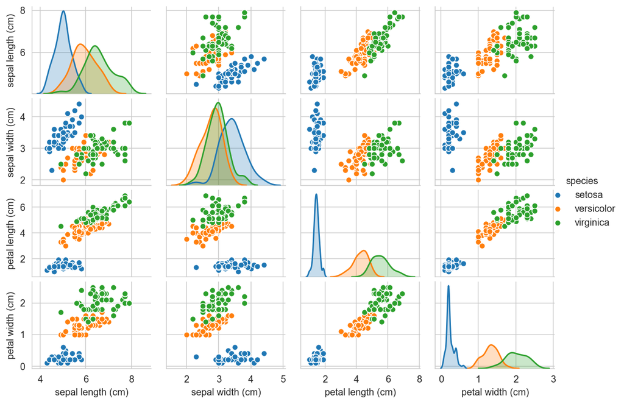

```python
import seaborn as sns
sns.set_style('whitegrid')
grid = sns.pairplot(data=iris_df, vars=iris_df.columns[0:4], hue='species')
grid.fig.set_size_inches(9, 5.5)
```

## 14.7.4 Using a `KMeans` Estimator

- Use k-means clustering via **`KMeans` estimator** to place each sample in the Iris dataset into a cluster

### Creating the `KMeans` Estimator

- [`KMeans` default arguments](https://scikit-learn.org/stable/modules/generated/sklearn.cluster.KMeans.html)
- When you **train a `KMeans` estimator**, it calculates for each cluster a **centroid** representing the **cluster’s center data point**
  - Often, you’ll rely on **domain experts** to help **choose an appropriate *k*** (`n_clusters`).
- Can also use **hyperparameter tuning** to estimate the appropriate **k**

```python
from sklearn.cluster import KMeans

kmeans = KMeans(n_clusters=3, random_state=11)
```

### Fitting the Model Via the `KMeans` object’s `fit` Method

- When the training completes, the `KMeans` object contains:
  - **`labels_` array** with values from **`0` to `n_clusters - 1`**, indicating the clusters to which the samples belong
  - **`cluster_centers_` array** in which **each row represents a centroid**

```python
kmeans.fit(iris.data)
```

```
KMeans(n_clusters=3, random_state=11)
```

### Comparing the Cluster Labels to the Iris Dataset’s Target Values (1 of 2)

- **Iris dataset** is **labeled**, so we can look at **`target` array values** to get a sense of **how well the k-means algorithm clustered the samples**
  - With **unlabeled data**, we’d depend on a **domain expert** to help **evaluate whether the predicted classes make sense**
- First 50 samples are **Iris setosa**, next 50 are **Iris versicolor**, last 50 are **Iris virginica**
  - **`target` array** represents these with values **0–2**
- If **`KMeans` chose clusters perfectly**, then **each group of 50 elements in the estimator’s `labels_` array should have a distinct label**.
  - **`KMeans` labels** are **not related** to dataset’s **`target` array**

### Comparing the Cluster Labels to the Iris Dataset’s Target Values (2 of 2)

- First 50 samples should be **one cluster**

```python
print(kmeans.labels_[0:50])
```

```
[1 1 1 1 1 1 1 1 1 1 1 1 1 1 1 1 1 1 1 1 1 1 1 1 1 1 1 1 1 1 1 1 1 1 1 1 1
 1 1 1 1 1 1 1 1 1 1 1 1 1]
```

- Next 50 samples should be a **second cluster** (two are not)

```python
print(kmeans.labels_[50:100])
```

```
[0 0 2 0 0 0 0 0 0 0 0 0 0 0 0 0 0 0 0 0 0 0 0 0 0 0 0 2 0 0 0 0 0 0 0 0 0
 0 0 0 0 0 0 0 0 0 0 0 0 0]
```

- Last 50 samples should be a **third cluster** (14 are not)

```python
print(kmeans.labels_[100:150])
```

```
[2 0 2 2 2 2 0 2 2 2 2 2 2 0 0 2 2 2 2 0 2 0 2 0 2 2 0 0 2 2 2 2 2 0 2 2 2
 2 0 2 2 2 0 2 2 2 0 2 2 0]
```

- Results confirm what we saw in **`pairplot` diagrams**
  - **Iris setosa** is “in a class by itself”
  - There is confusion between **Iris versicolor** and **Iris virginica**

## 14.7.5 Dimensionality Reduction with Principal Component Analysis

- Use **`PCA` estimator** to perform dimensionality reduction from **4 to 2 dimensions**
  - [Algorithm’s details](https://scikit-learn.org/stable/modules/decomposition.html#pca) beyond scope

```python
from sklearn.decomposition import PCA
```

```python
pca = PCA(n_components=2, random_state=11)
```

### Transforming the Iris Dataset’s Features into Two Dimensions

```python
pca.fit(iris.data)  # trains estimator once
```

```
PCA(n_components=2, random_state=11)
```

```python
iris_pca = pca.transform(iris.data)  # can be called many times to reduce data
```

- We'll call **`transform`** again to **reduce the cluster centroids from four dimensions to two** for plotting
- **`transform`** returns an array with same number of rows as `iris.data`, but only two columns

```python
iris_pca.shape
```

```
(150, 2)
```

### Visualizing the Reduced Data in a Scatter Plot

- Place reduced data in a **`DataFrame`** and **add a species column** that we’ll use to **determine dot colors**

```python
iris_pca_df = pd.DataFrame(iris_pca,
                           columns=['Component1', 'Component2'])
```

```python
iris_pca_df['species'] = iris_df.species
```

```python
iris_pca_df.head()
```

|  | Component1 | Component2 | species |
| --- | --- | --- | --- |
| 0 | -2.68 | 0.32 | setosa |
| 1 | -2.71 | -0.18 | setosa |
| 2 | -2.89 | -0.14 | setosa |
| 3 | -2.75 | -0.32 | setosa |
| 4 | -2.73 | 0.33 | setosa |

### Scatterplot the Data with Seaborn

- Each **centroid** in **`cluster_centers_`** array has **same number of features** (four) as dataset's samples
- **To plot centroids**, we must **reduce their dimensions**
- Think of a **centroid** as the **“average” sample in its cluster**
  - So each centroid should be **transformed** using **same `PCA` estimator** as **other samples**

```python
kmeans.cluster_centers_
```

```
array([[5.9016129 , 2.7483871 , 4.39354839, 1.43387097],
       [5.006     , 3.428     , 1.462     , 0.246     ],
       [6.85      , 3.07368421, 5.74210526, 2.07105263]])
```

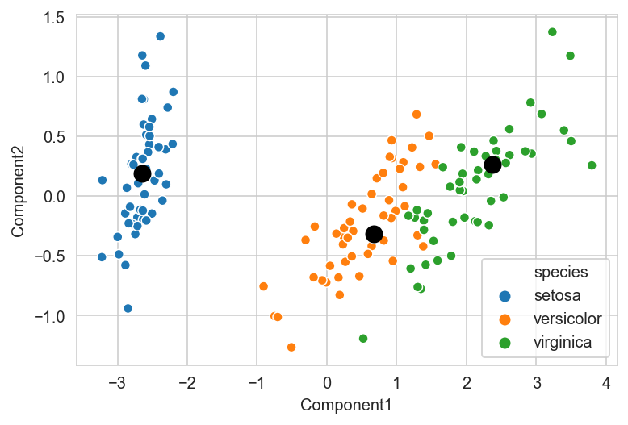

```python
axes = sns.scatterplot(data=iris_pca_df, x='Component1',
    y='Component2', hue='species', legend='brief')

# reduce centroids to 2 dimensions
iris_centers = pca.transform(kmeans.cluster_centers_)

# plot centroids as larger black dots
import matplotlib.pyplot as plt

dots = plt.scatter(iris_centers[:,0], iris_centers[:,1], s=100, c='k')
```

## 14.7.6 Choosing the Best Clustering Estimator (1 of 4)

- **Run multiple clustering algorithms** and see **how well they cluster Iris species**
  - We’re running `KMeans` here on the **small** Iris dataset
  - If you experience **performance problems with `KMeans`** on larger datasets, consider **`MiniBatchKMeans`**
  - Documentation indicates **`MiniBatchKMeans` is faster on large datasets** and the results are almost as good

## 14.7.6 Choosing the Best Clustering Estimator (2 of 4)

- For the `DBSCAN` and `MeanShift` estimators, we do **not** specify number of clusters in advance

```python
from sklearn.cluster import DBSCAN, MeanShift,\
    SpectralClustering, AgglomerativeClustering
```

```python
estimators = {
    'KMeans': kmeans,
    'DBSCAN': DBSCAN(),
    'MeanShift': MeanShift(),
    'SpectralClustering': SpectralClustering(n_clusters=3),
    'AgglomerativeClustering':
        AgglomerativeClustering(n_clusters=3)
}
```

## 14.7.6 Choosing the Best Clustering Estimator (3 of 4)

```python
import numpy as np
```

```python
for name, estimator in estimators.items():
    estimator.fit(iris.data)
    print(f'\n{name}:')
    for i in range(0, 101, 50):
        labels, counts = np.unique(
            estimator.labels_[i:i+50], return_counts=True)
        print(f'{i}-{i+50}:')
        for label, count in zip(labels, counts):
            print(f'   label={label}, count={count}')
```

```
KMeans:
0-50:
   label=1, count=50
50-100:
   label=0, count=48
   label=2, count=2
100-150:
   label=0, count=14
   label=2, count=36

DBSCAN:
0-50:
   label=-1, count=1
   label=0, count=49
50-100:
   label=-1, count=6
   label=1, count=44
100-150:
   label=-1, count=10
   label=1, count=40

MeanShift:
0-50:
   label=1, count=50
50-100:
   label=0, count=49
   label=1, count=1
100-150:
   label=0, count=50

SpectralClustering:
0-50:
   label=1, count=50
50-100:
   label=2, count=50
100-150:
   label=0, count=35
   label=2, count=15

AgglomerativeClustering:
0-50:
   label=1, count=50
50-100:
   label=0, count=49
   label=2, count=1
100-150:
   label=0, count=15
   label=2, count=35
```

## 14.7.6 Choosing the Best Clustering Estimator (4 of 4)

- **`DBSCAN` correctly predicted three clusters** (labeled `-1`, `0` and `1`)
  - Placed 84 of the 100 **Iris virginica** and **Iris versicolor** in the same cluster
- **`MeanShift` predicted only two clusters** (labeled as `0` and `1`)
  - Placed 99 of 100 **Iris virginica** and **Iris versicolor** samples in same cluster

# More Info

- See Lesson 14 in [**Python Fundamentals LiveLessons** here on O'Reilly Online Learning](https://learning.oreilly.com/videos/python-fundamentals/9780135917411)
- See Chapter 14 in [**Python for Programmers** on O'Reilly Online Learning](https://learning.oreilly.com/library/view/python-for-programmers/9780135231364/)
- See Chapter 15 in [**Intro Python for Computer Science and Data Science** on O'Reilly Online Learning](https://learning.oreilly.com/library/view/intro-to-python/9780135404799/)
- Interested in a print book? Check out:

| Python for Programmers (640-page professional book) | Intro to Python for Computer Science and Data Science (880-page college textbook) |
| --- | --- |

> Please **do not** purchase both books—*Python for Programmers* is a subset of *Intro to Python for Computer Science and Data Science*

© 2019 by Pearson Education, Inc. All Rights Reserved. The content in this notebook is based on the book [**Python for Programmers**](https://amzn.to/2VvdnxE).